# act_report

## Analysis report of WeRateDogs

#### After wrangling the data I chose to take a look at these aspects of the data.

1. Top 10 predicted dog breeds
2. What tweet was retweeted the most?
3. Top 10 rated numerators
4. What tweet recieved the highest favourites?
5. What was the most common dog stage?

### Top 10 predicted dog breeds

As the graph below shows, the Golden retreiver was the most frequently predicted dog at just below 120.

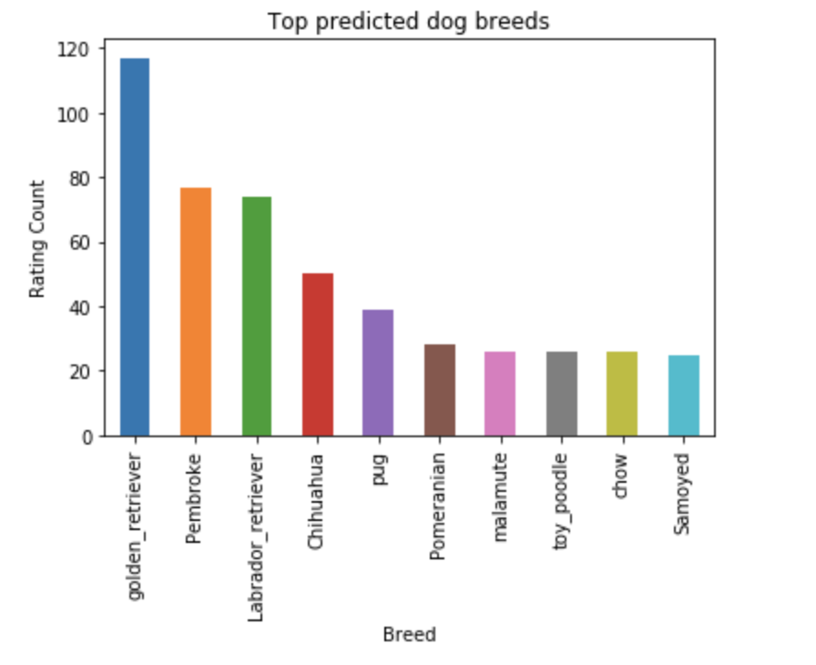

### What tweet was retweeted the most?

At 56615 this was the most retweeted tweet.

Some info on the below dog:

- No name
- Was rated 13/10
- Had a favourite count of 113442
- Stage is Doggo

[figure not shown]

### Top 10 most commom numerator ratings

As the graph below shows, on just over 300 ocassions a dog was rated 12/10. Although there were some big numerators in the data set, these seemed to be a low enough occurence to mean they weren't in the top 10.

Both of the most favourited and most retweeted dogs were given a rating of 13/10 which is the 4th most common rating, as the graph below shows.

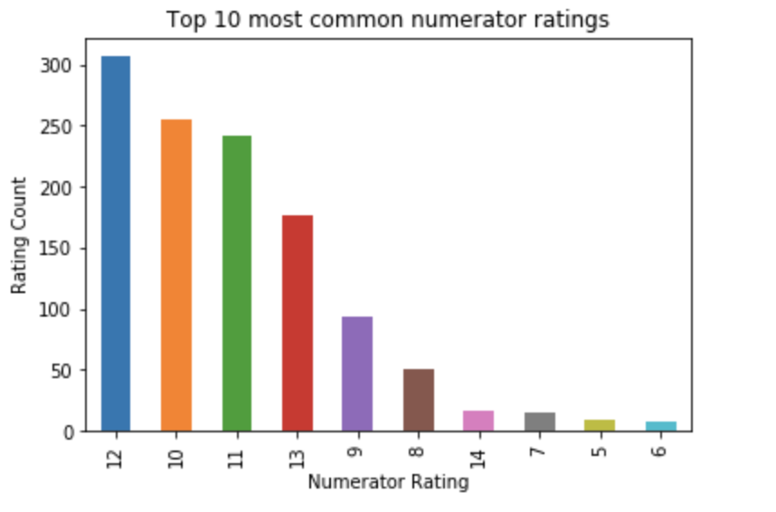

### What tweet received the highest numer of favourites?

At 130853 this was the highest favourited tweet.

Some info on the below dog.

- No name
- Was rated 13/10
- Had a retweet count of 42906
- Stage is Puppo

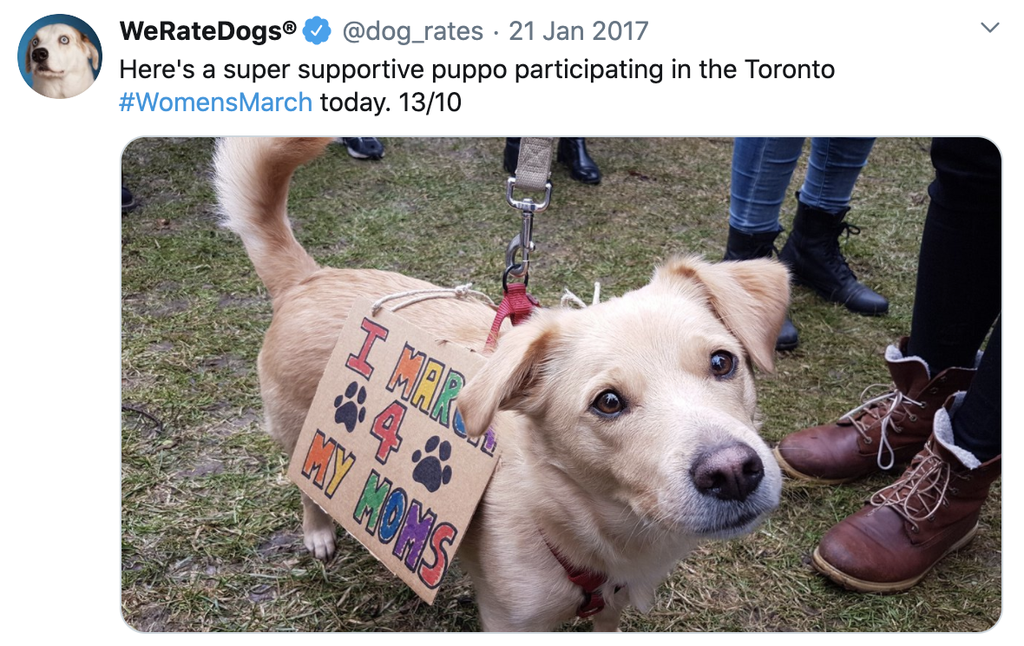

## What dog stage was most common

As we can see from the below graph, the most common dog stage (3x more common than the second most common) was pupper.

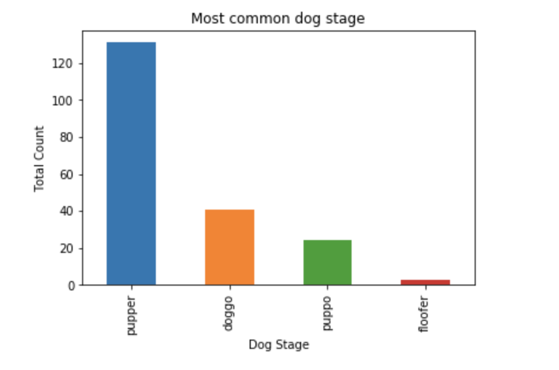

### Conclusion

Some interesting analysis from this step of the project and given more time and scope there would have been further opportunity to explore the data. However, even with the limited analysis there was some interesting findings